# Risk Factor Analysis

## Outcome Variable

**Outcome Variable:** whz

## Predictor Variables

**Intervention Variable:** predfeed3

**Adjustment Set:**

- arm
- sex
- month
- brthmon
- W_mage
- meducyrs
- feducyrs
- hhwealth_quart
- hfoodsec
- W_mhtcm
- W_mwtkg
- W_mbmi
- vagbrth
- W_gagebrth
- W_birthwt
- W_birthlen
- W_nrooms
- W_nchldlt5
- W_parity
- impfloor
- impsan
- safeh20
- delta_W_mage
- delta_meducyrs
- delta_feducyrs
- delta_hhwealth_quart
- delta_hfoodsec
- delta_W_mhtcm
- delta_W_mwtkg
- delta_W_mbmi
- delta_vagbrth
- delta_W_gagebrth
- delta_W_birthwt
- delta_W_birthlen
- delta_W_nrooms
- delta_W_nchldlt5
- delta_W_parity
- delta_impfloor
- delta_impsan
- delta_safeh20

## Stratifying Variables

The analysis was stratified on these variable(s):

- agecat
- studyid
- country

## Data Summary

| agecat | studyid | country | predfeed3 | n_cell | n |
| --- | --- | --- | --- | --- | --- |
| Birth | ki0047075b-MAL-ED | BANGLADESH | 1 | 164 | 202 |
| Birth | ki0047075b-MAL-ED | BANGLADESH | 0 | 38 | 202 |
| Birth | ki0047075b-MAL-ED | BRAZIL | 1 | 23 | 55 |
| Birth | ki0047075b-MAL-ED | BRAZIL | 0 | 32 | 55 |
| Birth | ki0047075b-MAL-ED | INDIA | 1 | 27 | 39 |
| Birth | ki0047075b-MAL-ED | INDIA | 0 | 12 | 39 |
| Birth | ki0047075b-MAL-ED | NEPAL | 1 | 14 | 25 |
| Birth | ki0047075b-MAL-ED | NEPAL | 0 | 11 | 25 |
| Birth | ki0047075b-MAL-ED | PERU | 1 | 145 | 218 |
| Birth | ki0047075b-MAL-ED | PERU | 0 | 73 | 218 |
| Birth | ki0047075b-MAL-ED | SOUTH AFRICA | 1 | 33 | 99 |
| Birth | ki0047075b-MAL-ED | SOUTH AFRICA | 0 | 66 | 99 |
| Birth | ki0047075b-MAL-ED | TANZANIA, UNITED REPUBLIC OF | 1 | 24 | 95 |
| Birth | ki0047075b-MAL-ED | TANZANIA, UNITED REPUBLIC OF | 0 | 71 | 95 |
| Birth | ki1000109-EE | PAKISTAN | 1 | 22 | 22 |
| Birth | ki1000109-EE | PAKISTAN | 0 | 0 | 22 |
| Birth | ki1113344-GMS-Nepal | NEPAL | 1 | 352 | 422 |
| Birth | ki1113344-GMS-Nepal | NEPAL | 0 | 70 | 422 |
| Birth | kiGH5241-JiVitA-3 | BANGLADESH | 1 | 9638 | 10634 |
| Birth | kiGH5241-JiVitA-3 | BANGLADESH | 0 | 996 | 10634 |
| Birth | kiGH5241-JiVitA-4 | BANGLADESH | 1 | 89 | 97 |
| Birth | kiGH5241-JiVitA-4 | BANGLADESH | 0 | 8 | 97 |
| 6 months | ki0047075b-MAL-ED | BANGLADESH | 1 | 191 | 233 |
| 6 months | ki0047075b-MAL-ED | BANGLADESH | 0 | 42 | 233 |
| 6 months | ki0047075b-MAL-ED | BRAZIL | 1 | 93 | 187 |
| 6 months | ki0047075b-MAL-ED | BRAZIL | 0 | 94 | 187 |
| 6 months | ki0047075b-MAL-ED | INDIA | 1 | 147 | 210 |
| 6 months | ki0047075b-MAL-ED | INDIA | 0 | 63 | 210 |
| 6 months | ki0047075b-MAL-ED | NEPAL | 1 | 113 | 227 |
| 6 months | ki0047075b-MAL-ED | NEPAL | 0 | 114 | 227 |
| 6 months | ki0047075b-MAL-ED | PERU | 1 | 176 | 270 |
| 6 months | ki0047075b-MAL-ED | PERU | 0 | 94 | 270 |
| 6 months | ki0047075b-MAL-ED | SOUTH AFRICA | 1 | 63 | 244 |
| 6 months | ki0047075b-MAL-ED | SOUTH AFRICA | 0 | 181 | 244 |
| 6 months | ki0047075b-MAL-ED | TANZANIA, UNITED REPUBLIC OF | 1 | 64 | 212 |
| 6 months | ki0047075b-MAL-ED | TANZANIA, UNITED REPUBLIC OF | 0 | 148 | 212 |
| 6 months | ki1000109-EE | PAKISTAN | 1 | 39 | 39 |
| 6 months | ki1000109-EE | PAKISTAN | 0 | 0 | 39 |
| 6 months | ki1113344-GMS-Nepal | NEPAL | 1 | 367 | 441 |
| 6 months | ki1113344-GMS-Nepal | NEPAL | 0 | 74 | 441 |
| 6 months | kiGH5241-JiVitA-3 | BANGLADESH | 1 | 8500 | 9310 |
| 6 months | kiGH5241-JiVitA-3 | BANGLADESH | 0 | 810 | 9310 |
| 6 months | kiGH5241-JiVitA-4 | BANGLADESH | 1 | 76 | 88 |
| 6 months | kiGH5241-JiVitA-4 | BANGLADESH | 0 | 12 | 88 |
| 24 months | ki0047075b-MAL-ED | BANGLADESH | 1 | 168 | 205 |
| 24 months | ki0047075b-MAL-ED | BANGLADESH | 0 | 37 | 205 |
| 24 months | ki0047075b-MAL-ED | BRAZIL | 1 | 79 | 152 |
| 24 months | ki0047075b-MAL-ED | BRAZIL | 0 | 73 | 152 |
| 24 months | ki0047075b-MAL-ED | INDIA | 1 | 139 | 202 |
| 24 months | ki0047075b-MAL-ED | INDIA | 0 | 63 | 202 |
| 24 months | ki0047075b-MAL-ED | NEPAL | 1 | 110 | 220 |
| 24 months | ki0047075b-MAL-ED | NEPAL | 0 | 110 | 220 |
| 24 months | ki0047075b-MAL-ED | PERU | 1 | 131 | 198 |
| 24 months | ki0047075b-MAL-ED | PERU | 0 | 67 | 198 |
| 24 months | ki0047075b-MAL-ED | SOUTH AFRICA | 1 | 60 | 228 |
| 24 months | ki0047075b-MAL-ED | SOUTH AFRICA | 0 | 168 | 228 |
| 24 months | ki0047075b-MAL-ED | TANZANIA, UNITED REPUBLIC OF | 1 | 54 | 184 |
| 24 months | ki0047075b-MAL-ED | TANZANIA, UNITED REPUBLIC OF | 0 | 130 | 184 |
| 24 months | ki1000109-EE | PAKISTAN | 1 | 20 | 20 |
| 24 months | ki1000109-EE | PAKISTAN | 0 | 0 | 20 |
| 24 months | ki1113344-GMS-Nepal | NEPAL | 1 | 322 | 384 |
| 24 months | ki1113344-GMS-Nepal | NEPAL | 0 | 62 | 384 |
| 24 months | kiGH5241-JiVitA-3 | BANGLADESH | 1 | 4417 | 4833 |
| 24 months | kiGH5241-JiVitA-3 | BANGLADESH | 0 | 416 | 4833 |
| 24 months | kiGH5241-JiVitA-4 | BANGLADESH | 1 | 135 | 150 |
| 24 months | kiGH5241-JiVitA-4 | BANGLADESH | 0 | 15 | 150 |

The following strata were considered:

- agecat: 24 months, studyid: ki0047075b-MAL-ED, country: BANGLADESH
- agecat: 24 months, studyid: ki0047075b-MAL-ED, country: BRAZIL
- agecat: 24 months, studyid: ki0047075b-MAL-ED, country: INDIA
- agecat: 24 months, studyid: ki0047075b-MAL-ED, country: NEPAL
- agecat: 24 months, studyid: ki0047075b-MAL-ED, country: PERU
- agecat: 24 months, studyid: ki0047075b-MAL-ED, country: SOUTH AFRICA
- agecat: 24 months, studyid: ki0047075b-MAL-ED, country: TANZANIA, UNITED REPUBLIC OF
- agecat: 24 months, studyid: ki1000109-EE, country: PAKISTAN
- agecat: 24 months, studyid: ki1113344-GMS-Nepal, country: NEPAL
- agecat: 24 months, studyid: kiGH5241-JiVitA-3, country: BANGLADESH
- agecat: 24 months, studyid: kiGH5241-JiVitA-4, country: BANGLADESH
- agecat: 6 months, studyid: ki0047075b-MAL-ED, country: BANGLADESH
- agecat: 6 months, studyid: ki0047075b-MAL-ED, country: BRAZIL
- agecat: 6 months, studyid: ki0047075b-MAL-ED, country: INDIA
- agecat: 6 months, studyid: ki0047075b-MAL-ED, country: NEPAL
- agecat: 6 months, studyid: ki0047075b-MAL-ED, country: PERU
- agecat: 6 months, studyid: ki0047075b-MAL-ED, country: SOUTH AFRICA
- agecat: 6 months, studyid: ki0047075b-MAL-ED, country: TANZANIA, UNITED REPUBLIC OF
- agecat: 6 months, studyid: ki1000109-EE, country: PAKISTAN
- agecat: 6 months, studyid: ki1113344-GMS-Nepal, country: NEPAL
- agecat: 6 months, studyid: kiGH5241-JiVitA-3, country: BANGLADESH
- agecat: 6 months, studyid: kiGH5241-JiVitA-4, country: BANGLADESH
- agecat: Birth, studyid: ki0047075b-MAL-ED, country: BANGLADESH
- agecat: Birth, studyid: ki0047075b-MAL-ED, country: BRAZIL
- agecat: Birth, studyid: ki0047075b-MAL-ED, country: INDIA
- agecat: Birth, studyid: ki0047075b-MAL-ED, country: NEPAL
- agecat: Birth, studyid: ki0047075b-MAL-ED, country: PERU
- agecat: Birth, studyid: ki0047075b-MAL-ED, country: SOUTH AFRICA
- agecat: Birth, studyid: ki0047075b-MAL-ED, country: TANZANIA, UNITED REPUBLIC OF
- agecat: Birth, studyid: ki1000109-EE, country: PAKISTAN
- agecat: Birth, studyid: ki1113344-GMS-Nepal, country: NEPAL
- agecat: Birth, studyid: kiGH5241-JiVitA-3, country: BANGLADESH
- agecat: Birth, studyid: kiGH5241-JiVitA-4, country: BANGLADESH

### Dropped Strata

- agecat: Birth, studyid: ki1000109-EE, country: PAKISTAN
- agecat: 6 months, studyid: ki1000109-EE, country: PAKISTAN
- agecat: 24 months, studyid: ki1000109-EE, country: PAKISTAN

## Methods Detail

We’re interested in the causal parameters $E[Y_a]$ for all values of $a \in \mathcal{A}$. These parameters represent the mean outcome if, possibly contrary to fact, we intervened to set all units to have $A=a$. Under the randomization and positivity assumptions, these are identified by the statistical parameters $\psi_a=E_W[E_{Y|A,W}(Y|A=a,W)]$. In addition, we’re interested in the mean of $Y$, $E[Y]$ under no intervention (the observed mean). We will estimate these parameters by using SuperLearner to fit the relevant likelihood factors – $E_{Y|A,W}(Y|A=a,W)$ and $p(A=a|W)$, and then updating our likelihood fit using a joint TMLE.

For unadjusted analyses ($W=\{\}$), initial likelihoods were estimated using Lrnr_glm to estimate the simple $E(Y|A)$ and Lrnr_mean to estimate $p(A)$. For adjusted analyses, a small library containing Lrnr_glmnet, Lrnr_xgboost, and Lrnr_mean was used.

Having estimated these parameters, we will then use the delta method to estimate relative risks and attributable risks relative to a prespecified baseline level of $A$.

# Results Detail

## Results Plots

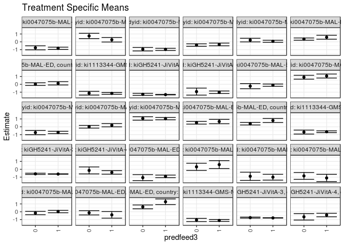

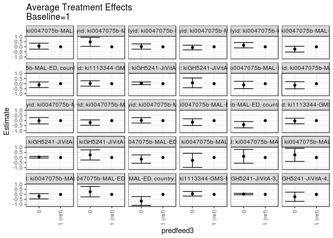

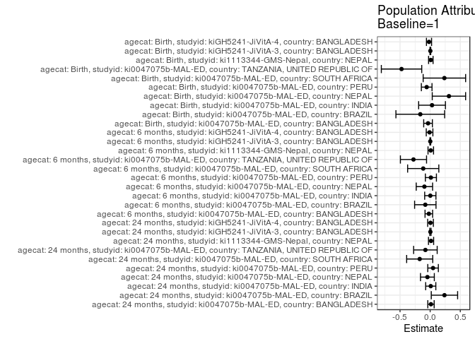

## Results Table

### Parameter: TSM

| agecat | studyid | country | intervention_level | baseline_level | estimate | ci_lower | ci_upper |
| --- | --- | --- | --- | --- | --- | --- | --- |
| Birth | ki0047075b-MAL-ED | BANGLADESH | 1 | NA | -0.9058082 | -1.0702434 | -0.7413730 |
| Birth | ki0047075b-MAL-ED | BANGLADESH | 0 | NA | -1.0632891 | -1.4420270 | -0.6845513 |
| Birth | ki0047075b-MAL-ED | BRAZIL | 1 | NA | 0.5956576 | 0.0875943 | 1.1037209 |
| Birth | ki0047075b-MAL-ED | BRAZIL | 0 | NA | 0.3135691 | -0.1455791 | 0.7727172 |
| Birth | ki0047075b-MAL-ED | INDIA | 1 | NA | -1.0089055 | -1.3770060 | -0.6408049 |
| Birth | ki0047075b-MAL-ED | INDIA | 0 | NA | -0.8939073 | -1.4169854 | -0.3708292 |
| Birth | ki0047075b-MAL-ED | NEPAL | 1 | NA | -1.1057254 | -1.5683389 | -0.6431120 |
| Birth | ki0047075b-MAL-ED | NEPAL | 0 | NA | -0.8451965 | -1.2808817 | -0.4095113 |
| Birth | ki0047075b-MAL-ED | PERU | 1 | NA | 0.0243426 | -0.1267193 | 0.1754045 |
| Birth | ki0047075b-MAL-ED | PERU | 0 | NA | -0.1620388 | -0.3741213 | 0.0500437 |
| Birth | ki0047075b-MAL-ED | SOUTH AFRICA | 1 | NA | -0.3948903 | -0.8175655 | 0.0277848 |
| Birth | ki0047075b-MAL-ED | SOUTH AFRICA | 0 | NA | -0.1320747 | -0.4046730 | 0.1405237 |
| Birth | ki0047075b-MAL-ED | TANZANIA, UNITED REPUBLIC OF | 1 | NA | 1.2748398 | 0.9122804 | 1.6373991 |
| Birth | ki0047075b-MAL-ED | TANZANIA, UNITED REPUBLIC OF | 0 | NA | 0.6192008 | 0.3732666 | 0.8651350 |
| Birth | ki1113344-GMS-Nepal | NEPAL | 1 | NA | -1.1099573 | -1.2283271 | -0.9915874 |
| Birth | ki1113344-GMS-Nepal | NEPAL | 0 | NA | -1.0471642 | -1.2539389 | -0.8403896 |
| Birth | kiGH5241-JiVitA-3 | BANGLADESH | 1 | NA | -0.7830116 | -0.8062461 | -0.7597772 |
| Birth | kiGH5241-JiVitA-3 | BANGLADESH | 0 | NA | -0.7497610 | -0.8162467 | -0.6832753 |
| Birth | kiGH5241-JiVitA-4 | BANGLADESH | 1 | NA | -0.4156180 | -0.6383645 | -0.1928714 |
| Birth | kiGH5241-JiVitA-4 | BANGLADESH | 0 | NA | -0.6475000 | -1.0569566 | -0.2380434 |
| 6 months | ki0047075b-MAL-ED | BANGLADESH | 1 | NA | -0.1082391 | -0.2537169 | 0.0372387 |
| 6 months | ki0047075b-MAL-ED | BANGLADESH | 0 | NA | -0.2340463 | -0.5625880 | 0.0944955 |
| 6 months | ki0047075b-MAL-ED | BRAZIL | 1 | NA | 1.0561225 | 0.8028740 | 1.3093710 |
| 6 months | ki0047075b-MAL-ED | BRAZIL | 0 | NA | 0.9035958 | 0.6574657 | 1.1497260 |
| 6 months | ki0047075b-MAL-ED | INDIA | 1 | NA | -0.7208577 | -0.8691766 | -0.5725389 |
| 6 months | ki0047075b-MAL-ED | INDIA | 0 | NA | -0.7363213 | -1.0091981 | -0.4634445 |
| 6 months | ki0047075b-MAL-ED | NEPAL | 1 | NA | 0.1997681 | -0.0056015 | 0.4051378 |
| 6 months | ki0047075b-MAL-ED | NEPAL | 0 | NA | 0.0067314 | -0.1671983 | 0.1806610 |
| 6 months | ki0047075b-MAL-ED | PERU | 1 | NA | 1.0394471 | 0.8923110 | 1.1865831 |
| 6 months | ki0047075b-MAL-ED | PERU | 0 | NA | 1.0626548 | 0.8415912 | 1.2837184 |
| 6 months | ki0047075b-MAL-ED | SOUTH AFRICA | 1 | NA | 0.6717180 | 0.3886690 | 0.9547670 |
| 6 months | ki0047075b-MAL-ED | SOUTH AFRICA | 0 | NA | 0.5167139 | 0.3411249 | 0.6923029 |
| 6 months | ki0047075b-MAL-ED | TANZANIA, UNITED REPUBLIC OF | 1 | NA | 0.8028128 | 0.5434167 | 1.0622089 |
| 6 months | ki0047075b-MAL-ED | TANZANIA, UNITED REPUBLIC OF | 0 | NA | 0.3940166 | 0.2314021 | 0.5566312 |
| 6 months | ki1113344-GMS-Nepal | NEPAL | 1 | NA | -0.6300407 | -0.7403747 | -0.5197068 |
| 6 months | ki1113344-GMS-Nepal | NEPAL | 0 | NA | -0.6707292 | -0.9226167 | -0.4188418 |
| 6 months | kiGH5241-JiVitA-3 | BANGLADESH | 1 | NA | -0.6061053 | -0.6316784 | -0.5805323 |
| 6 months | kiGH5241-JiVitA-3 | BANGLADESH | 0 | NA | -0.5795431 | -0.6571035 | -0.5019827 |
| 6 months | kiGH5241-JiVitA-4 | BANGLADESH | 1 | NA | -0.4010532 | -0.6278778 | -0.1742286 |
| 6 months | kiGH5241-JiVitA-4 | BANGLADESH | 0 | NA | -0.1474188 | -0.5901275 | 0.2952900 |
| 24 months | ki0047075b-MAL-ED | BANGLADESH | 1 | NA | -0.8211926 | -0.9604990 | -0.6818862 |
| 24 months | ki0047075b-MAL-ED | BANGLADESH | 0 | NA | -0.7600900 | -1.0173615 | -0.5028184 |
| 24 months | ki0047075b-MAL-ED | BRAZIL | 1 | NA | 0.2608883 | -0.0279846 | 0.5497611 |
| 24 months | ki0047075b-MAL-ED | BRAZIL | 0 | NA | 0.7478745 | 0.4082544 | 1.0874946 |
| 24 months | ki0047075b-MAL-ED | INDIA | 1 | NA | -0.9612751 | -1.1013064 | -0.8212437 |
| 24 months | ki0047075b-MAL-ED | INDIA | 0 | NA | -0.9360124 | -1.1565658 | -0.7154591 |
| 24 months | ki0047075b-MAL-ED | NEPAL | 1 | NA | -0.3331944 | -0.5044857 | -0.1619031 |
| 24 months | ki0047075b-MAL-ED | NEPAL | 0 | NA | -0.4099208 | -0.5662313 | -0.2536103 |
| 24 months | ki0047075b-MAL-ED | PERU | 1 | NA | 0.0696597 | -0.0618438 | 0.2011632 |
| 24 months | ki0047075b-MAL-ED | PERU | 0 | NA | 0.2237200 | -0.0092358 | 0.4566757 |
| 24 months | ki0047075b-MAL-ED | SOUTH AFRICA | 1 | NA | 0.5858861 | 0.3369615 | 0.8348106 |
| 24 months | ki0047075b-MAL-ED | SOUTH AFRICA | 0 | NA | 0.3494625 | 0.2091790 | 0.4897460 |
| 24 months | ki0047075b-MAL-ED | TANZANIA, UNITED REPUBLIC OF | 1 | NA | 0.1286793 | -0.0827682 | 0.3401269 |
| 24 months | ki0047075b-MAL-ED | TANZANIA, UNITED REPUBLIC OF | 0 | NA | 0.0243723 | -0.1470677 | 0.1958123 |
| 24 months | ki1113344-GMS-Nepal | NEPAL | 1 | NA | -1.1543908 | -1.2670852 | -1.0416965 |
| 24 months | ki1113344-GMS-Nepal | NEPAL | 0 | NA | -1.1305153 | -1.3703738 | -0.8906568 |
| 24 months | kiGH5241-JiVitA-3 | BANGLADESH | 1 | NA | -1.3145140 | -1.3463261 | -1.2827018 |
| 24 months | kiGH5241-JiVitA-3 | BANGLADESH | 0 | NA | -1.2756576 | -1.4022900 | -1.1490251 |
| 24 months | kiGH5241-JiVitA-4 | BANGLADESH | 1 | NA | -1.0153082 | -1.1784100 | -0.8522065 |
| 24 months | kiGH5241-JiVitA-4 | BANGLADESH | 0 | NA | -0.9299223 | -1.3784993 | -0.4813453 |

### Parameter: E(Y)

| agecat | studyid | country | intervention_level | baseline_level | estimate | ci_lower | ci_upper |
| --- | --- | --- | --- | --- | --- | --- | --- |
| Birth | ki0047075b-MAL-ED | BANGLADESH | NA | NA | -0.9411386 | -1.0895370 | -0.7927402 |
| Birth | ki0047075b-MAL-ED | BRAZIL | NA | NA | 0.4316364 | 0.0969688 | 0.7663039 |
| Birth | ki0047075b-MAL-ED | INDIA | NA | NA | -0.9779487 | -1.2664810 | -0.6894164 |
| Birth | ki0047075b-MAL-ED | NEPAL | NA | NA | -0.7944000 | -1.1625222 | -0.4262778 |
| Birth | ki0047075b-MAL-ED | PERU | NA | NA | -0.0335321 | -0.1564905 | 0.0894263 |
| Birth | ki0047075b-MAL-ED | SOUTH AFRICA | NA | NA | -0.1588889 | -0.3845288 | 0.0667510 |
| Birth | ki0047075b-MAL-ED | TANZANIA, UNITED REPUBLIC OF | NA | NA | 0.7996842 | 0.5874808 | 1.0118876 |
| Birth | ki1113344-GMS-Nepal | NEPAL | NA | NA | -1.0991706 | -1.2073693 | -0.9909719 |
| Birth | kiGH5241-JiVitA-3 | BANGLADESH | NA | NA | -0.7798636 | -0.8022140 | -0.7575133 |
| Birth | kiGH5241-JiVitA-4 | BANGLADESH | NA | NA | -0.4347423 | -0.6441144 | -0.2253701 |
| 6 months | ki0047075b-MAL-ED | BANGLADESH | NA | NA | -0.1304936 | -0.2625419 | 0.0015547 |
| 6 months | ki0047075b-MAL-ED | BRAZIL | NA | NA | 0.9754144 | 0.7990651 | 1.1517638 |
| 6 months | ki0047075b-MAL-ED | INDIA | NA | NA | -0.7185992 | -0.8491469 | -0.5880515 |
| 6 months | ki0047075b-MAL-ED | NEPAL | NA | NA | 0.1041483 | -0.0311352 | 0.2394318 |
| 6 months | ki0047075b-MAL-ED | PERU | NA | NA | 1.0514136 | 0.9289176 | 1.1739096 |
| 6 months | ki0047075b-MAL-ED | SOUTH AFRICA | NA | NA | 0.5564071 | 0.4055220 | 0.7072922 |
| 6 months | ki0047075b-MAL-ED | TANZANIA, UNITED REPUBLIC OF | NA | NA | 0.5257626 | 0.3871543 | 0.6643709 |
| 6 months | ki1113344-GMS-Nepal | NEPAL | NA | NA | -0.6198791 | -0.7206518 | -0.5191063 |
| 6 months | kiGH5241-JiVitA-3 | BANGLADESH | NA | NA | -0.6040977 | -0.6286619 | -0.5795335 |
| 6 months | kiGH5241-JiVitA-4 | BANGLADESH | NA | NA | -0.4110227 | -0.6122701 | -0.2097753 |
| 24 months | ki0047075b-MAL-ED | BANGLADESH | NA | NA | -0.8076829 | -0.9296166 | -0.6857493 |
| 24 months | ki0047075b-MAL-ED | BRAZIL | NA | NA | 0.4981140 | 0.2760418 | 0.7201863 |
| 24 months | ki0047075b-MAL-ED | INDIA | NA | NA | -0.9516832 | -1.0703961 | -0.8329703 |
| 24 months | ki0047075b-MAL-ED | NEPAL | NA | NA | -0.3790455 | -0.4958857 | -0.2622052 |
| 24 months | ki0047075b-MAL-ED | PERU | NA | NA | 0.1176052 | -0.0015211 | 0.2367315 |
| 24 months | ki0047075b-MAL-ED | SOUTH AFRICA | NA | NA | 0.4120797 | 0.2900939 | 0.5340654 |
| 24 months | ki0047075b-MAL-ED | TANZANIA, UNITED REPUBLIC OF | NA | NA | 0.0495743 | -0.0857535 | 0.1849021 |
| 24 months | ki1113344-GMS-Nepal | NEPAL | NA | NA | -1.1396441 | -1.2416403 | -1.0376479 |
| 24 months | kiGH5241-JiVitA-3 | BANGLADESH | NA | NA | -1.3109518 | -1.3423299 | -1.2795737 |
| 24 months | kiGH5241-JiVitA-4 | BANGLADESH | NA | NA | -1.0096000 | -1.1619164 | -0.8572836 |

### Parameter: ATE

| agecat | studyid | country | intervention_level | baseline_level | estimate | ci_lower | ci_upper |
| --- | --- | --- | --- | --- | --- | --- | --- |
| Birth | ki0047075b-MAL-ED | BANGLADESH | 1 | 1 | 0.0000000 | 0.0000000 | 0.0000000 |
| Birth | ki0047075b-MAL-ED | BANGLADESH | 0 | 1 | -0.1574809 | -0.5711812 | 0.2562194 |
| Birth | ki0047075b-MAL-ED | BRAZIL | 1 | 1 | 0.0000000 | 0.0000000 | 0.0000000 |
| Birth | ki0047075b-MAL-ED | BRAZIL | 0 | 1 | -0.2820885 | -0.9782206 | 0.4140435 |
| Birth | ki0047075b-MAL-ED | INDIA | 1 | 1 | 0.0000000 | 0.0000000 | 0.0000000 |
| Birth | ki0047075b-MAL-ED | INDIA | 0 | 1 | 0.1149982 | -0.5658914 | 0.7958877 |
| Birth | ki0047075b-MAL-ED | NEPAL | 1 | 1 | 0.0000000 | 0.0000000 | 0.0000000 |
| Birth | ki0047075b-MAL-ED | NEPAL | 0 | 1 | 0.2605290 | -0.3874982 | 0.9085561 |
| Birth | ki0047075b-MAL-ED | PERU | 1 | 1 | 0.0000000 | 0.0000000 | 0.0000000 |
| Birth | ki0047075b-MAL-ED | PERU | 0 | 1 | -0.1863814 | -0.4476483 | 0.0748855 |
| Birth | ki0047075b-MAL-ED | SOUTH AFRICA | 1 | 1 | 0.0000000 | 0.0000000 | 0.0000000 |
| Birth | ki0047075b-MAL-ED | SOUTH AFRICA | 0 | 1 | 0.2628157 | -0.2500908 | 0.7757222 |
| Birth | ki0047075b-MAL-ED | TANZANIA, UNITED REPUBLIC OF | 1 | 1 | 0.0000000 | 0.0000000 | 0.0000000 |
| Birth | ki0047075b-MAL-ED | TANZANIA, UNITED REPUBLIC OF | 0 | 1 | -0.6556390 | -1.0950894 | -0.2161885 |
| Birth | ki1113344-GMS-Nepal | NEPAL | 1 | 1 | 0.0000000 | 0.0000000 | 0.0000000 |
| Birth | ki1113344-GMS-Nepal | NEPAL | 0 | 1 | 0.0627931 | -0.1632445 | 0.2888307 |
| Birth | kiGH5241-JiVitA-3 | BANGLADESH | 1 | 1 | 0.0000000 | 0.0000000 | 0.0000000 |
| Birth | kiGH5241-JiVitA-3 | BANGLADESH | 0 | 1 | 0.0332506 | -0.0355584 | 0.1020596 |
| Birth | kiGH5241-JiVitA-4 | BANGLADESH | 1 | 1 | 0.0000000 | 0.0000000 | 0.0000000 |
| Birth | kiGH5241-JiVitA-4 | BANGLADESH | 0 | 1 | -0.2318820 | -0.6871466 | 0.2233826 |
| 6 months | ki0047075b-MAL-ED | BANGLADESH | 1 | 1 | 0.0000000 | 0.0000000 | 0.0000000 |
| 6 months | ki0047075b-MAL-ED | BANGLADESH | 0 | 1 | -0.1258072 | -0.4847976 | 0.2331833 |
| 6 months | ki0047075b-MAL-ED | BRAZIL | 1 | 1 | 0.0000000 | 0.0000000 | 0.0000000 |
| 6 months | ki0047075b-MAL-ED | BRAZIL | 0 | 1 | -0.1525267 | -0.5069256 | 0.2018723 |
| 6 months | ki0047075b-MAL-ED | INDIA | 1 | 1 | 0.0000000 | 0.0000000 | 0.0000000 |
| 6 months | ki0047075b-MAL-ED | INDIA | 0 | 1 | -0.0154636 | -0.3267227 | 0.2957955 |
| 6 months | ki0047075b-MAL-ED | NEPAL | 1 | 1 | 0.0000000 | 0.0000000 | 0.0000000 |
| 6 months | ki0047075b-MAL-ED | NEPAL | 0 | 1 | -0.1930368 | -0.4607257 | 0.0746521 |
| 6 months | ki0047075b-MAL-ED | PERU | 1 | 1 | 0.0000000 | 0.0000000 | 0.0000000 |
| 6 months | ki0047075b-MAL-ED | PERU | 0 | 1 | 0.0232077 | -0.2424810 | 0.2888963 |
| 6 months | ki0047075b-MAL-ED | SOUTH AFRICA | 1 | 1 | 0.0000000 | 0.0000000 | 0.0000000 |
| 6 months | ki0047075b-MAL-ED | SOUTH AFRICA | 0 | 1 | -0.1550041 | -0.4893254 | 0.1793172 |
| 6 months | ki0047075b-MAL-ED | TANZANIA, UNITED REPUBLIC OF | 1 | 1 | 0.0000000 | 0.0000000 | 0.0000000 |
| 6 months | ki0047075b-MAL-ED | TANZANIA, UNITED REPUBLIC OF | 0 | 1 | -0.4087962 | -0.7150217 | -0.1025706 |
| 6 months | ki1113344-GMS-Nepal | NEPAL | 1 | 1 | 0.0000000 | 0.0000000 | 0.0000000 |
| 6 months | ki1113344-GMS-Nepal | NEPAL | 0 | 1 | -0.0406885 | -0.3160487 | 0.2346717 |
| 6 months | kiGH5241-JiVitA-3 | BANGLADESH | 1 | 1 | 0.0000000 | 0.0000000 | 0.0000000 |
| 6 months | kiGH5241-JiVitA-3 | BANGLADESH | 0 | 1 | 0.0265623 | -0.0542198 | 0.1073444 |
| 6 months | kiGH5241-JiVitA-4 | BANGLADESH | 1 | 1 | 0.0000000 | 0.0000000 | 0.0000000 |
| 6 months | kiGH5241-JiVitA-4 | BANGLADESH | 0 | 1 | 0.2536344 | -0.2466372 | 0.7539061 |
| 24 months | ki0047075b-MAL-ED | BANGLADESH | 1 | 1 | 0.0000000 | 0.0000000 | 0.0000000 |
| 24 months | ki0047075b-MAL-ED | BANGLADESH | 0 | 1 | 0.0611026 | -0.2341043 | 0.3563096 |
| 24 months | ki0047075b-MAL-ED | BRAZIL | 1 | 1 | 0.0000000 | 0.0000000 | 0.0000000 |
| 24 months | ki0047075b-MAL-ED | BRAZIL | 0 | 1 | 0.4869863 | 0.0427818 | 0.9311907 |
| 24 months | ki0047075b-MAL-ED | INDIA | 1 | 1 | 0.0000000 | 0.0000000 | 0.0000000 |
| 24 months | ki0047075b-MAL-ED | INDIA | 0 | 1 | 0.0252626 | -0.2352820 | 0.2858072 |
| 24 months | ki0047075b-MAL-ED | NEPAL | 1 | 1 | 0.0000000 | 0.0000000 | 0.0000000 |
| 24 months | ki0047075b-MAL-ED | NEPAL | 0 | 1 | -0.0767264 | -0.3056283 | 0.1521755 |
| 24 months | ki0047075b-MAL-ED | PERU | 1 | 1 | 0.0000000 | 0.0000000 | 0.0000000 |
| 24 months | ki0047075b-MAL-ED | PERU | 0 | 1 | 0.1540602 | -0.1089297 | 0.4170502 |
| 24 months | ki0047075b-MAL-ED | SOUTH AFRICA | 1 | 1 | 0.0000000 | 0.0000000 | 0.0000000 |
| 24 months | ki0047075b-MAL-ED | SOUTH AFRICA | 0 | 1 | -0.2364236 | -0.5224044 | 0.0495572 |
| 24 months | ki0047075b-MAL-ED | TANZANIA, UNITED REPUBLIC OF | 1 | 1 | 0.0000000 | 0.0000000 | 0.0000000 |
| 24 months | ki0047075b-MAL-ED | TANZANIA, UNITED REPUBLIC OF | 0 | 1 | -0.1043070 | -0.3773804 | 0.1687663 |
| 24 months | ki1113344-GMS-Nepal | NEPAL | 1 | 1 | 0.0000000 | 0.0000000 | 0.0000000 |
| 24 months | ki1113344-GMS-Nepal | NEPAL | 0 | 1 | 0.0238755 | -0.2417549 | 0.2895060 |
| 24 months | kiGH5241-JiVitA-3 | BANGLADESH | 1 | 1 | 0.0000000 | 0.0000000 | 0.0000000 |
| 24 months | kiGH5241-JiVitA-3 | BANGLADESH | 0 | 1 | 0.0388564 | -0.0900959 | 0.1678086 |
| 24 months | kiGH5241-JiVitA-4 | BANGLADESH | 1 | 1 | 0.0000000 | 0.0000000 | 0.0000000 |
| 24 months | kiGH5241-JiVitA-4 | BANGLADESH | 0 | 1 | 0.0853859 | -0.3946184 | 0.5653902 |

### Parameter: PAR

| agecat | studyid | country | intervention_level | baseline_level | estimate | ci_lower | ci_upper |
| --- | --- | --- | --- | --- | --- | --- | --- |
| Birth | ki0047075b-MAL-ED | BANGLADESH | 1 | NA | -0.0353304 | -0.1072566 | 0.0365958 |
| Birth | ki0047075b-MAL-ED | BRAZIL | 1 | NA | -0.1640212 | -0.5684844 | 0.2404420 |
| Birth | ki0047075b-MAL-ED | INDIA | 1 | NA | 0.0309568 | -0.1912848 | 0.2531983 |
| Birth | ki0047075b-MAL-ED | NEPAL | 1 | NA | 0.3113254 | 0.0344634 | 0.5881874 |
| Birth | ki0047075b-MAL-ED | PERU | 1 | NA | -0.0578747 | -0.1461762 | 0.0304268 |
| Birth | ki0047075b-MAL-ED | SOUTH AFRICA | 1 | NA | 0.2360014 | -0.1163073 | 0.5883102 |
| Birth | ki0047075b-MAL-ED | TANZANIA, UNITED REPUBLIC OF | 1 | NA | -0.4751556 | -0.8103547 | -0.1399565 |
| Birth | ki1113344-GMS-Nepal | NEPAL | 1 | NA | 0.0107867 | -0.0264376 | 0.0480109 |
| Birth | kiGH5241-JiVitA-3 | BANGLADESH | 1 | NA | 0.0031480 | -0.0033278 | 0.0096237 |
| Birth | kiGH5241-JiVitA-4 | BANGLADESH | 1 | NA | -0.0191243 | -0.0615870 | 0.0233385 |
| 6 months | ki0047075b-MAL-ED | BANGLADESH | 1 | NA | -0.0222545 | -0.0850857 | 0.0405768 |
| 6 months | ki0047075b-MAL-ED | BRAZIL | 1 | NA | -0.0807081 | -0.2582696 | 0.0968534 |
| 6 months | ki0047075b-MAL-ED | INDIA | 1 | NA | 0.0022585 | -0.0910507 | 0.0955678 |
| 6 months | ki0047075b-MAL-ED | NEPAL | 1 | NA | -0.0956198 | -0.2312278 | 0.0399882 |
| 6 months | ki0047075b-MAL-ED | PERU | 1 | NA | 0.0119665 | -0.0798266 | 0.1037596 |
| 6 months | ki0047075b-MAL-ED | SOUTH AFRICA | 1 | NA | -0.1153109 | -0.3741133 | 0.1434915 |
| 6 months | ki0047075b-MAL-ED | TANZANIA, UNITED REPUBLIC OF | 1 | NA | -0.2770502 | -0.4940347 | -0.0600657 |
| 6 months | ki1113344-GMS-Nepal | NEPAL | 1 | NA | 0.0101617 | -0.0357146 | 0.0560380 |
| 6 months | kiGH5241-JiVitA-3 | BANGLADESH | 1 | NA | 0.0020076 | -0.0050135 | 0.0090287 |
| 6 months | kiGH5241-JiVitA-4 | BANGLADESH | 1 | NA | -0.0099695 | -0.0649757 | 0.0450367 |
| 24 months | ki0047075b-MAL-ED | BANGLADESH | 1 | NA | 0.0135097 | -0.0392921 | 0.0663115 |
| 24 months | ki0047075b-MAL-ED | BRAZIL | 1 | NA | 0.2372258 | 0.0188436 | 0.4556079 |
| 24 months | ki0047075b-MAL-ED | INDIA | 1 | NA | 0.0095919 | -0.0745369 | 0.0937206 |
| 24 months | ki0047075b-MAL-ED | NEPAL | 1 | NA | -0.0458510 | -0.1604719 | 0.0687698 |
| 24 months | ki0047075b-MAL-ED | PERU | 1 | NA | 0.0479455 | -0.0397789 | 0.1356699 |
| 24 months | ki0047075b-MAL-ED | SOUTH AFRICA | 1 | NA | -0.1738064 | -0.3902124 | 0.0425996 |
| 24 months | ki0047075b-MAL-ED | TANZANIA, UNITED REPUBLIC OF | 1 | NA | -0.0791051 | -0.2746299 | 0.1164198 |
| 24 months | ki1113344-GMS-Nepal | NEPAL | 1 | NA | 0.0147467 | -0.0281148 | 0.0576083 |
| 24 months | kiGH5241-JiVitA-3 | BANGLADESH | 1 | NA | 0.0035622 | -0.0069019 | 0.0140263 |
| 24 months | kiGH5241-JiVitA-4 | BANGLADESH | 1 | NA | 0.0057082 | -0.0415328 | 0.0529492 |